# Bevers

## Introduction

Reynolds (1994) describes a small part of a study of the long-term temperature dynamics of beaver Castor canadensis in north-central Wisconsin. Body temperature was measured by telemetry every 10 minutes for four females, but data from a one period of less than a day for each of two animals is used there.

The vast majority of the text and code are taken from the `beavers` data documentation page.

```r
# This code below is what's needed to process our dataset
# the beaver datasets are builtin the R programming language
# you do not need to do anything to use the dataset,
# but we will be processing them

bev1 <- beaver1 |>
  dplyr::mutate(
    bev_num = 1,
    hours = time %/% 100 + 24*(day - day[1]) + (time %% 100)/60
  )

bev2 <- beaver2 |>
  dplyr::mutate(
    bev_num = 2,
    hours = time %/% 100 + 24*(day - day[1]) + (time %% 100)/60
  )

bevs <- dplyr::bind_rows(bev1, bev2) |>
  dplyr::mutate(
    activ_char = purrr::map_chr(activ, recode_activ)
  )

# the bev data is what we will use for other parts of the analysis
```

## Data description

In our processed data, we have combined data from the original `beaver1` and `beaver2`. The below table shows how many time observations for each beaver.

```r
# this table calculation should be loaded in the final report
bev_num_counts <- bevs |>
  dplyr::count(bev_num)
```

```r
# this table should be displayed in the report
bev_num_counts |>
  knitr::kable()
```

| bev_num | n |
| --- | --- |
| 1 | 114 |
| 2 | 100 |

The main columns of our data are as follows:

- `day`: Day of observation (in days since the beginning of 1990), December 12–13 (beaver1) and November 3–4 (beaver2).
- `time`: Time of observation, in the form `0330` for 3:30am
- `temp`: Measured body temperature in degrees Celsius
- `activ`: Indicator of activity outside the retreat

Below we are counting the recoded `activ` column, `activ_char` by the `bev_num`

```r
# there is a table calculation here that ends up being displayed in the final report
activ_char_counts <- bevs |>
  dplyr::count(bev_num, activ_char)

activ_char_counts |>
  knitr::kable()
```

| bev_num | activ_char | n |
| --- | --- | --- |
| 1 | active | 6 |
| 1 | inactive | 108 |
| 2 | active | 62 |
| 2 | inactive | 38 |

We also have a figure looking at temperatures of each beaver over time. The red points are when the beaver was active.

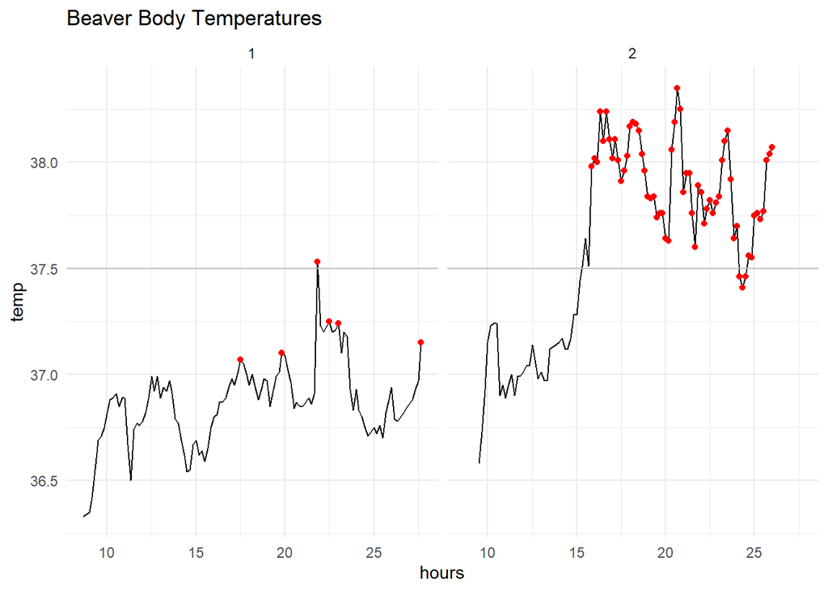

```r
# this is a figure that should be saved and loaded into the report
g <- ggplot(bevs) +
  geom_line(aes(x = hours, y = temp)) +
  geom_point(
    data = dplyr::filter(bevs, activ == 1),
    aes(x = hours, y = temp),
    color = "red"
  ) +
  geom_hline(yintercept = 37.5, color = "grey") +
  facet_grid(~bev_num) +
  ggtitle("Beaver Body Temperatures") +
  theme_minimal()

g
```

## References

P. S. Reynolds (1994) Time-series analyses of beaver body temperatures. Chapter 11 of Lange, N., Ryan, L., Billard, L., Brillinger, D., Conquest, L. and Greenhouse, J. eds (1994) Case Studies in Biometry. New York: John Wiley and Sons.